# Stress-Prospection-Intertemporal Choice: Study 1 Analysis

Hayoung Ahn

March 2021 (last updated June 2021)

## 1. Introduction

This study looks at the effects of stress on our ability to make decisions for our personal future. Through the Trier Social Stress Test and an “Imagine” cue that prompts participants to prospect about their future, we are curious to see whether stress interacts with memory to influence the decisions you make during intertemporal choice. http://rmarkdown.rstudio.com.

First, let’s load in the data collected from Cognition.run (downloaded as .csv files from jsPsych task code). We’ll create one big dataframe (called `bigdf`) that appends all participants’ data together into matching columns.

29 participants were enrolled in the study; 4 participants were excluded due to no-shows/cancellations or incomplete data. Hence, 25 participants are included in this study sample.

```r
# Load subjects' data ------------------------------------------------
setwd('~/Box Sync/Bakkour-Lab/users/hayoung/stress_prospection_data/SONA_prelim_analysis')
myfiles = list.files(path = "data", pattern = "*.csv", full.names=TRUE)
bigdf = ldply(myfiles, read.csv)

# adjust rows to indicate which choices are imagine trials
bigdf$imagine[2:dim(bigdf)[1]] = bigdf$ttype[1:dim(bigdf)[1]-1]

# reassign prompt values to 1 or 0 to match newer csvs' imagine columns
bigdf$writeout[bigdf$imagine == 'imagine_writeout' | bigdf$imagine == 'describe_writeout'] <- 1
bigdf$writeout[bigdf$imagine == 'imagine' | bigdf$imagine == 'describe'] <- 0

bigdf$imagine[bigdf$imagine == 'imagine' | bigdf$imagine == 'imagine_writeout'] <- 1
bigdf$imagine[bigdf$imagine == 'describe'| bigdf$imagine == 'describe_writeout'] <- 0

#bigdf$choselater
bigdf$choselater[bigdf$ttype == 'choice' & bigdf$key_press == 75] <- 1
bigdf$choselater[bigdf$ttype == 'choice' & bigdf$key_press == 74] <- 0

write.csv(bigdf,'~/Box Sync/Bakkour-Lab/users/hayoung/stress_prospection_data/SONA_prelim_analysis/bigdf.csv')

# Specify which subjects had their Session 1 = Stress
subsstressfirst = c(3,6,10,11,13,16,17,20,23,24,26)
```

## 2. Fitting hyperbolic discounting function (k)

### Define the function

In order to develop a measure of “impulsivity” with intertemporal choice, we estimated the individual k-values (discounting parameter) while assuming hyperbolic discounting. We followed the tutorial here: http://alexanderfengler.github.io/neuroeconomics/K-Estimation/.

```r
# Create hyperbolic discounting functions (k) ---------------------------------
## for a single choice
GetPChoice = function(k,sir,ldr,delay,choice) {
  if (choice == 75) {
    pchoice = exp(ldr/(1 + k*delay)) / (exp(sir) + exp(ldr/(1 + k*delay)))
  } else if (choice == 74) {
    pchoice = (1 -  (exp(ldr/(1 + k*delay)) / (exp(sir) + exp(ldr/(1 + k*delay)))))
  }
  return(pchoice)
}

# generate log likelihood (negative log to find minimization)
## iterating over trials
# sum negative log likelihoods to end up with a final likelihood for a given k
GenerateLogLik = function(cur_k){
  choiceprobs=rep(0,length(df$choice))
  for (i in 1:length(df$choice)){
    choiceprobs[i]=GetPChoice(cur_k,df$sir[i],df$ldr[i],df$delay[i],df$choice[i])
  }
  sumloglik = (-1)*(sum(log(choiceprobs)))
  if (sumloglik==Inf){
    sumloglik = 99999 #issue if this equals Inf
  }
  else {
    return(sumloglik)
  }
}
```

### Apply function to calculate individual k’s

```r
## Start big iterative for loop here ---------------------------------

# subset the amountlater/delay/choice for subject 1 session 1
# get k's from the function, and save out to a new dataframe (subject, session, k-value)

# define empty dataframe with three columns for iteration, group, and k
k_df = data.frame(subject=numeric(),session=character(),prompt=character(),
                  k=numeric(),prop.later=numeric(),mean.rt=numeric())
split_df = data.frame(subject=numeric(),session=character(),
                      prop.later.beginning=numeric(),prop.later.end=numeric())
#num_subjects = length(unique(bigdf$subject))
#num_sessions = length(unique(bigdf$session))

## for subjects (each iteration is a participant)
for (s in unique(bigdf$subject)) {
  if (s %in% subsstressfirst) {
    bigdf$sessionlabel[bigdf$subject == s & bigdf$session == 1] = 'stress'
    bigdf$sessionlabel[bigdf$subject == s & bigdf$session == 2] = 'nostress'
  } else {
    bigdf$sessionlabel[bigdf$subject == s & bigdf$session == 2] = 'stress'
    bigdf$sessionlabel[bigdf$subject == s & bigdf$session == 1] = 'nostress'
  }

  bigdf$promptlabel[bigdf$subject == s & bigdf$imagine == 1] <- 'imagine'
  bigdf$promptlabel[bigdf$subject == s & bigdf$imagine == 0] <- 'describe'

  # calculate k within each session
  for (sess in c('stress', 'nostress')) {
    validdf = bigdf[bigdf$subject == s & bigdf$sessionlabel == sess
                     & bigdf$ttype == 'choice' & bigdf$key_press %in% c(74,75), ]
    validdf$choice = as.numeric(validdf$key_press)
    validdf.beginning = validdf[validdf$trialnum %in% c(0:35),]
    validdf.end = validdf[validdf$trialnum %in% c(36:71),]

    prop.later.beginning = (length(validdf.beginning$choice[validdf.beginning$choice == 75]))/(length(validdf.beginning$choice))
    prop.later.end = (length(validdf.end$choice[validdf.end$choice == 75]))/(length(validdf.end$choice))

    split_df = rbind(split_df, data.frame(subject=c(s), session=c(sess),
                    prop.later.beginning=c(prop.later.beginning), prop.later.end=c(prop.later.end)))

    # calculate k within each prompt
    for (p in c('imagine', 'describe')) {
      sessdf = bigdf[bigdf$subject == s & bigdf$sessionlabel == sess
                     & bigdf$promptlabel == p
                     & bigdf$ttype == 'choice' & bigdf$key_press %in% c(74,75), ]
      #numvalidtrials = length(sessdf$subject)
      sessdf$sir = as.numeric(sessdf$amounttoday) #rep(20, numvalidtrials) # have to specify that these variables are part of sessdf, because they will be used by GenerateLogLik later
      sessdf$ldr = as.numeric(sessdf$amountlater)
      sessdf$delay = as.numeric(sessdf$delay) # have to turn this list (characters) into numeric vectors to plug into function
      sessdf$choice = as.numeric(sessdf$key_press)

    # search the space of k's to find the best fitting k, $xmin (minimize likelihood)
    #fminbnd, find minimum of single-variable function on fixed interval (0,1)
      df = sessdf # have to specify what "df" is to input into GenerateLogLik function
      k = fminbnd(GenerateLogLik,0,1)$xmin

      # (num of trials where choice=75)/(numtrials)
      prop.later = (length(sessdf$choice[sessdf$choice == 75]))/(length(sessdf$choice))

      mean.rt = mean(as.numeric(sessdf$rt))

      # save out into k_df
      k_df = rbind(k_df, data.frame(subject=c(s),session=c(sess),prompt=c(p),
                                    k=c(k),prop.later=c(prop.later),mean.rt=c(mean.rt)))

    } # end of prompt loop
  } # end of sess loop
} # end of subject loop

# save local copy of dataframe "k_df"
path_out = '~/Box Sync/Bakkour-Lab/users/hayoung/stress_prospection_data/SONA_prelim_analysis/'
fileName = paste(path_out, 'k_df.csv', sep='')
write.csv(k_df, fileName, row.names=FALSE)
```

## 3. Calculate proportion of choices that were AmountLater

Examine the proportion of choices that were “amountlater.”

Each participant has a prop.later for each group (4 for each participant). Out of all the trials where they made a response, how many are amountlater choices?

In the plot: show the average of participants’ prop.later in each group

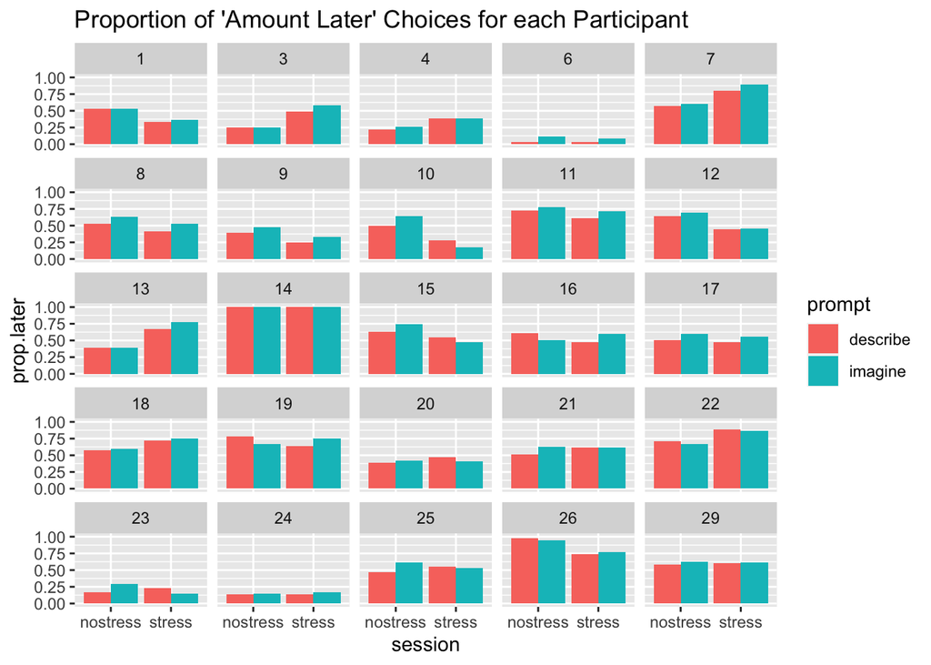

```r
# Small multiple plots for each of the 25 participants
ggplot(k_df, aes(fill=prompt, y=prop.later, x=session)) +
    geom_bar(position="dodge", stat="identity") +
  ggtitle("Proportion of 'Amount Later' Choices for each Participant") +
  facet_wrap(~subject)
```

```r
mean(k_df$prop.later[k_df$session=='stress'])
```

```
## [1] 0.5264674
```

```r
mean(k_df$prop.later[k_df$session=='nostress'])
```

```
## [1] 0.5324669
```

```r
mean(k_df$prop.later[k_df$prompt=='imagine'])
```

```
## [1] 0.5470373
```

```r
mean(k_df$prop.later[k_df$prompt=='describe'])
```

```
## [1] 0.5118969
```

```r
# take the mean across participants in a group
grouped.mean.proplater <- tapply(k_df$prop.later, list(as.factor(k_df$prompt), as.factor(k_df$session)), mean)
grouped.mean.proplater
```

```
##           nostress    stress
## describe 0.5122073 0.5115866
## imagine  0.5527264 0.5413483
```

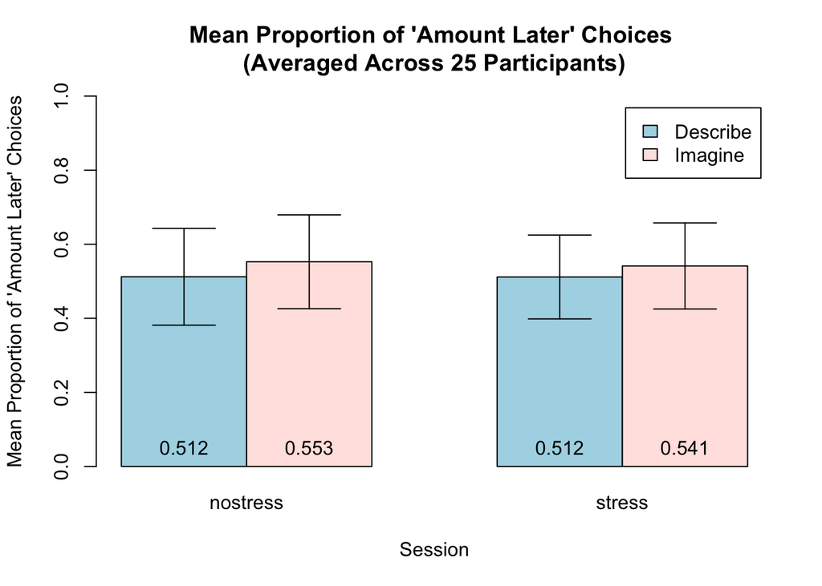

```r
# Remove 'between-subject variability'
## within each subject, calculate mean prop.later to average out the 4 sessions per subject
subject.mean = tapply(k_df$prop.later, list(as.factor(k_df$subject)), mean)
sample.mean = mean(k_df$prop.later)

# normalize prop.later within each subject
#prop.later.adj = prop.later - subject.mean + sample.mean
counter = 1
for (i in unique(k_df$subject)) {
  k_df$prop.later.adj[k_df$subject == i] = k_df$prop.later[k_df$subject == i] - subject.mean[counter] + sample.mean
  counter = counter + 1
}

# Create within-subject error bars
## standard deviation of adjusted prop.later
standard.deviation = tapply(k_df$prop.later.adj, list(as.factor(k_df$prompt), as.factor(k_df$session)), sd)

# get 4 standard errors for each Group
standard.error = (standard.deviation)/(sqrt(length(unique(k_df$subject))))
upper = grouped.mean.proplater + 1.96*(standard.error)
lower = grouped.mean.proplater - 1.96*(standard.error)

# this is the main part that plots the bar graph
bp.prop.later <- barplot2(grouped.mean.proplater, beside=TRUE,
      main="Mean Proportion of 'Amount Later' Choices \n(Averaged Across 25 Participants)",
      ylim=c(0,1), col=c("lightblue", "mistyrose"),
      plot.ci=TRUE, ci.u=upper, ci.l=lower,
      #names.arg = c("Stress Imagine", "Stress Describe", "Nostress Imagine", "Nostress Describe"),
      xlab="Session", ylab="Mean Proportion of 'Amount Later' Choices",
      legend=c("Describe","Imagine"))
      #args.legend=list(title="Prompt", x="topright", cex=.7))

text(bp.prop.later, 0, round(grouped.mean.proplater,3), cex=1, pos=3)
```

```r
# mathsd = tapply(k_df$prop.later, list(as.factor(k_df$prompt), as.factor(k_df$session)), sd)
# upper = grouped.mean + 1.96*(mathsd)
# lower = grouped.mean - 1.96*(mathsd)
```

## 4. Calculate k (discounting parameter)

Now let’s plot the k values for the four groups. For error bars, we want to make sure to plot within-subject error bars and not between-subjects.

Refer to this link for a step-by-step tutorial: http://www.cogsci.nl/blog/tutorials/156-an-easy-way-to-create-graphs-with-within-subject-error-bars

```r
# take the mean across participants in a group
grouped.mean.k <- tapply(k_df$k, list(as.factor(k_df$prompt), as.factor(k_df$session)), mean)
grouped.mean.k
```

```
##            nostress     stress
## describe 0.03258057 0.05868859
## imagine  0.02312454 0.05931601
```

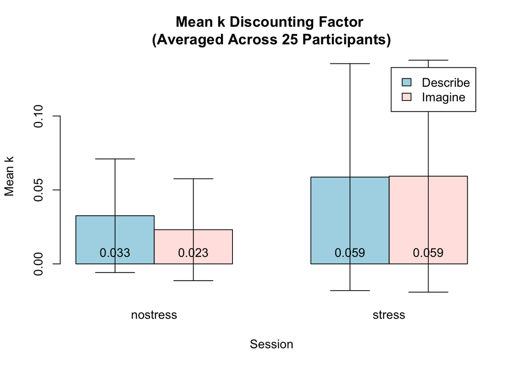

```r
# Remove 'between-subject variability'
## within each subject, calculate mean prop.later to average out the 4 sessions per subject
subject.mean = tapply(k_df$k, list(as.factor(k_df$subject)), mean)
sample.mean = mean(k_df$k)

# normalize prop.later within each subject
#k.adj = k - subject.mean + sample.mean
counter = 1
for (i in unique(k_df$subject)) {
  k_df$k.adj[k_df$subject == i] = k_df$k[k_df$subject == i] - subject.mean[counter] + sample.mean
  counter = counter + 1
}

# Create within-subject error bars
## standard deviation of adjusted prop.later
standard.deviation = tapply(k_df$k.adj, list(as.factor(k_df$prompt), as.factor(k_df$session)), sd)

# get 4 standard errors for each Group
standard.error = (standard.deviation)/(sqrt(length(unique(k_df$subject))))
upper = grouped.mean.k + 1.96*(standard.error)
lower = grouped.mean.k - 1.96*(standard.error)

# this is the main part that plots the bar graph
bp.k <- barplot2(grouped.mean.k, beside=TRUE,
      main="Mean k Discounting Factor \n(Averaged Across 25 Participants)",
      col=c("lightblue", "mistyrose"),
      plot.ci=TRUE, ci.u=upper, ci.l=lower,
      xlab="Session", ylab="Mean k",
      legend=c("Describe","Imagine"))

text(bp.k, 0, round(grouped.mean.k,3), cex=1, pos=3)
```

## 5. Restrict data to writeout-trials only: Calculate prop.later and k

Let’s start to restrict the data to see if any other patterns come up. What if we restricted the data to trials where participants are instructed to write out their responses (untimed), instead of simply thinking about it in their heads? Is there a change in the effect at all? Only include writeout trials (where writeout == 1).

Now that we’ve restricted the data to only take writeout trials, let’s plot prop.later (proportion of choices that were the AmountLater choice and not the $20 today).

```
##           nostress    stress
## describe 0.4960000 0.4960000
## imagine  0.5973333 0.5813333
```

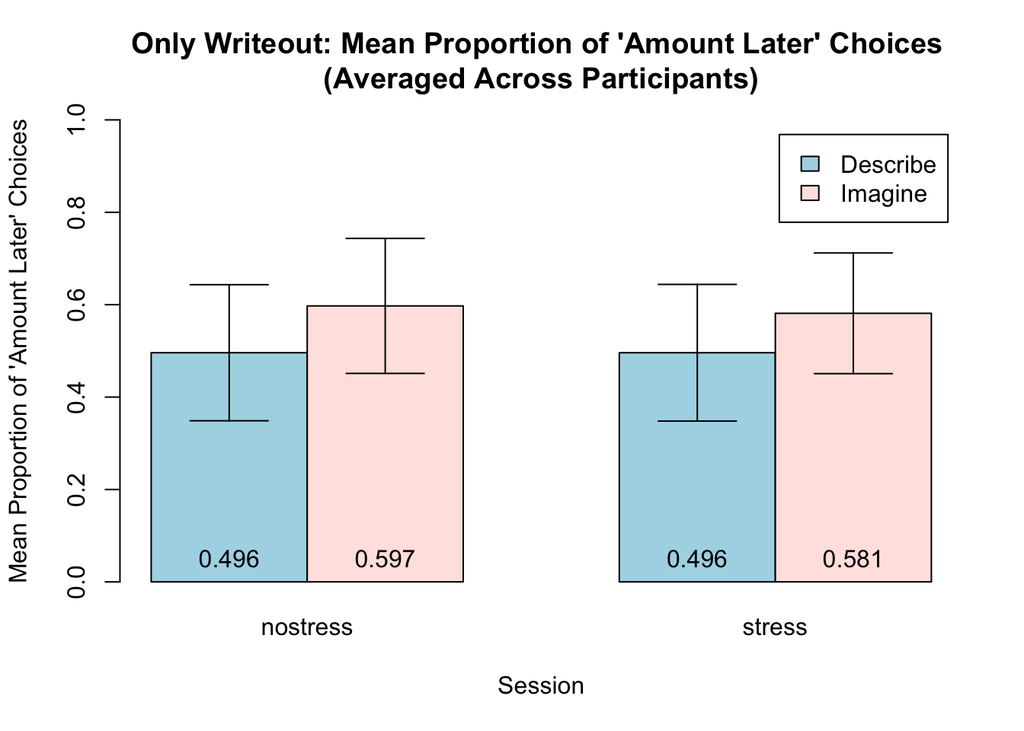

Likewise, now that we’ve restricted the data to only take writeout trials, let’s plot k (discounting parameter).

```
##           nostress     stress
## describe 0.1700674 0.14584596
## imagine  0.1220524 0.09332806
```

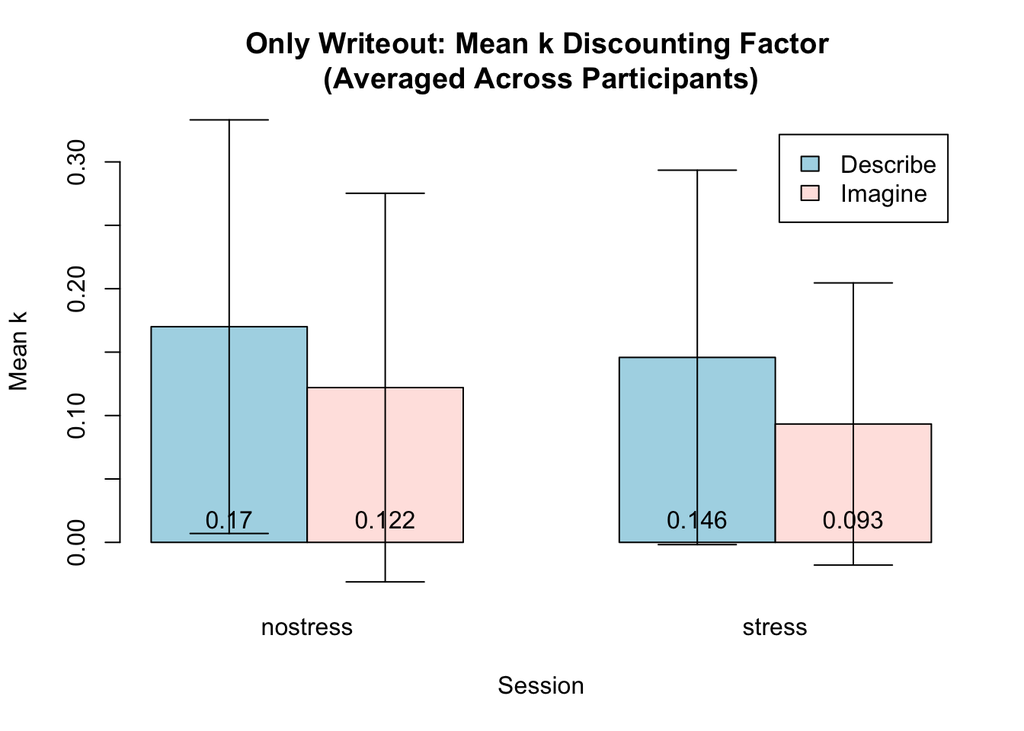

## 6. Model the data?

Run two-way repeated measures ANOVA to see main effect of stress / imagine; interaction of stress*imagine

```r
#k.aov <- anova_test(data = k_df, dv = k, wid = subject, within = c(session, prompt))
#get_anova_table(k.aov)

# k.aov <- aov(k ~ session*prompt, data = k_df)
# summary(k.aov)
# par(mfrow=c(2,2))
# plot(k.aov)
```

repeated measures t-test within prompt, within session [subset the data] (imagine-describe) within stress, one-sample t-test on the difference

Is there any significant difference in mean k during imagine trials vs. describe trials? Is there any significant difference in mean k during stress sessions vs. no-stress sessions?

```r
# t-test within prompt
imagine <- k_df[k_df$prompt == 'imagine',]$k
describe <- k_df[k_df$prompt == 'describe',]$k

t.test(imagine, describe, paired=TRUE, alternative="two.sided")
```

```
##
##  Paired t-test
##
## data:  imagine and describe
## t = -0.19438, df = 49, p-value = 0.8467
## alternative hypothesis: true difference in means is not equal to 0
## 95 percent confidence interval:
##  -0.05005178  0.04122317
## sample estimates:
## mean of the differences
##            -0.004414304
```

```r
# t-test within session
stress <- k_df[k_df$session == 'stress',]$k
nostress <- k_df[k_df$session == 'nostress',]$k

t.test(stress, nostress, paired=TRUE, alternative="two.sided")
```

```
##
##  Paired t-test
##
## data:  stress and nostress
## t = 1.436, df = 49, p-value = 0.1573
## alternative hypothesis: true difference in means is not equal to 0
## 95 percent confidence interval:
##  -0.01244077  0.07474028
## sample estimates:
## mean of the differences
##              0.03114975
```

### Generalized Linear Mixed-Effects Model

- interaction logistic regression model; mixed effects model with random effects for interaction input is 1’s for choselater and 0’s for chosenow. binomial family (1 and 0). tend to not converge, but let’s test it anyway.

glmer(choice ~ session*imagine + (session*imagine | subject), data = bigdf, family=‘binomial’)

variables from bigdf: subject choselater (1,0) sessionlabel (stress, nostress) promptlabel (imagine, describe, NA)

```r
mod = glmer(choselater ~ sessionlabel*promptlabel + (sessionlabel*promptlabel | subject), data = bigdf, family='binomial')
```

```
## boundary (singular) fit: see ?isSingular
```

```r
summary(mod)
```

```
## Generalized linear mixed model fit by maximum likelihood (Laplace
##   Approximation) [glmerMod]
##  Family: binomial  ( logit )
## Formula:
## choselater ~ sessionlabel * promptlabel + (sessionlabel * promptlabel |
##     subject)
##    Data: bigdf
##
##      AIC      BIC   logLik deviance df.resid
##   4247.3   4333.7  -2109.6   4219.3     3517
##
## Scaled residuals:
##     Min      1Q  Median      3Q     Max
## -3.3781 -0.8914  0.1494  0.8235  4.0237
##
## Random effects:
##  Groups  Name                                  Variance Std.Dev. Corr
##  subject (Intercept)                           1.96627  1.4022
##          sessionlabelstress                    0.39539  0.6288   -0.43
##          promptlabelimagine                    0.05524  0.2350   -0.85 -0.12
##          sessionlabelstress:promptlabelimagine 0.11938  0.3455    0.71  0.33
##
##
##
##
##  -0.98
## Number of obs: 3531, groups:  subject, 25
##
## Fixed effects:
##                                       Estimate Std. Error z value Pr(>|z|)
## (Intercept)                            0.11192    0.29224   0.383    0.702
## sessionlabelstress                    -0.01794    0.16750  -0.107    0.915
## promptlabelimagine                     0.18563    0.11684   1.589    0.112
## sessionlabelstress:promptlabelimagine -0.02724    0.16682  -0.163    0.870
##
## Correlation of Fixed Effects:
##             (Intr) sssnlb prmptl
## sssnlblstrs -0.437
## prmptlblmgn -0.499  0.256
## sssnlblstr:  0.403 -0.298 -0.751
## optimizer (Nelder_Mead) convergence code: 0 (OK)
## boundary (singular) fit: see ?isSingular
```

## 7. Alternative plots for k, the discounting factor

Possible visualizations:

- proportion of times that you choose later (1s and 0s)
- regression models
- raincloud plot to visualize variability in k’s: (imagine - describe) for stress session & no-stress session
- use lines to connect subject data points
- barplot with individual plot points connected

### How do individual participants’ discounting factors (k) change between their two sessions?

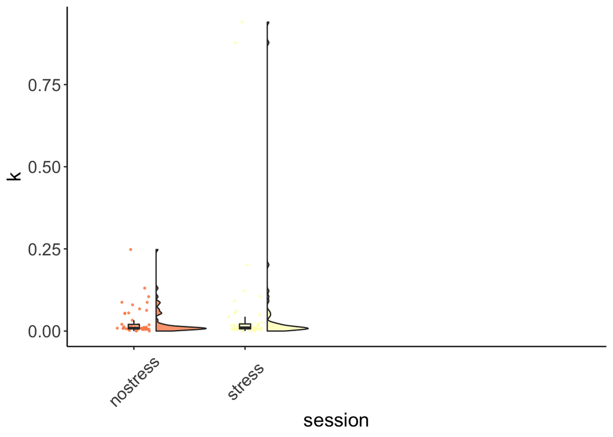

```r
# Visualizations -----------------------------------------------------------

# raincloud plot
ggplot(data = k_df, aes(y = k, x = session, fill = session)) +
  geom_flat_violin(position = position_nudge(x = .2, y = 0), alpha = .8) +
  geom_point(aes(y = k, color = session), position = position_jitter(width = .15), size = .5, alpha = 0.8) +
  geom_boxplot(width = .1, guides = FALSE, outlier.shape = NA, alpha = 0.5) +
  expand_limits(x = 5.25) +
  guides(fill = FALSE) +
  guides(color = FALSE) +
  scale_color_brewer(palette = "Spectral") +
  scale_fill_brewer(palette = "Spectral") +
  #coord_flip() +
  theme_bw() +
  raincloud_theme # raincloud_theme defined in 'Set up packages' section
```

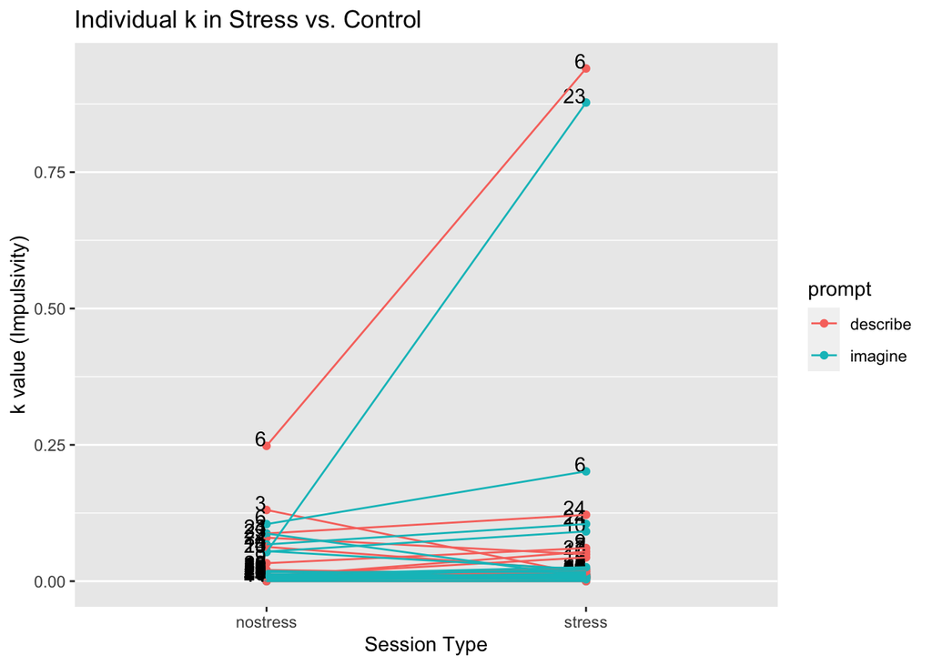

```r
# scatterplot
ggplot(data = k_df, aes(x=session, y=k, label=subject, color=prompt)) +
  geom_point(aes(color=prompt)) +
  geom_text(vjust = "bottom", hjust = "right", color='black') +
  #coord_cartesian(ylim = c(0, 0.2)) +
  theme(panel.grid.minor.x=element_blank(),
          panel.grid.major.x=element_blank()) +
  labs(title="Individual k in Stress vs. Control",
       x="Session Type", y="k value (Impulsivity)") +
  geom_line(aes(group = interaction(subject,prompt))) #paired lines based on both subject AND prompt
```

mean(session_diff_imagine) = 0.03619148

mean(session_diff_describe) = 0.02610803

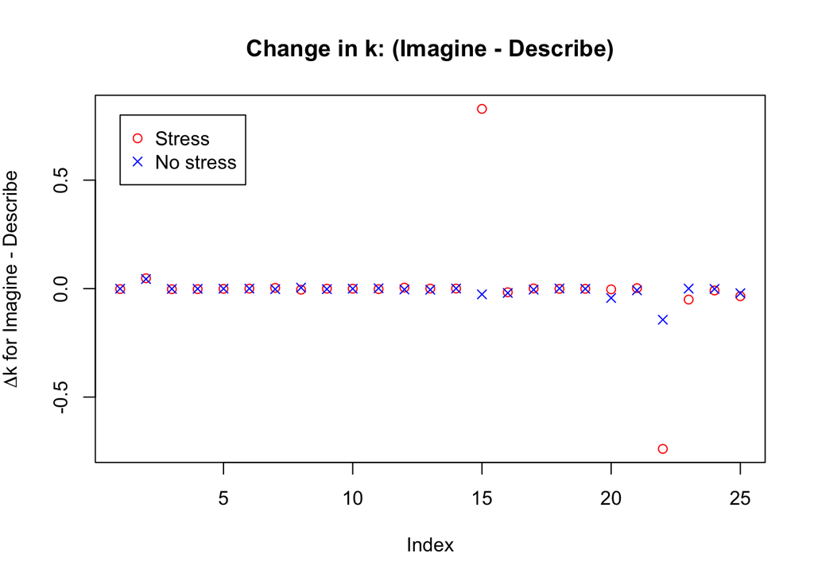

```r
# change in k = (imagine - describe)
prompt_diff_stress <- k_df[k_df$session == 'stress' & k_df$prompt == 'imagine',]$k - k_df[k_df$session == 'stress' & k_df$prompt == 'describe',]$k
prompt_diff_nostress <- k_df[k_df$session == 'nostress' & k_df$prompt == 'imagine',]$k - k_df[k_df$session == 'nostress' & k_df$prompt == 'describe',]$k
plot(prompt_diff_stress, col = 'red', pch=1,
     main="Change in k: (Imagine - Describe)", ylab=expression(paste(Delta,"k for Imagine - Describe")))
points(prompt_diff_nostress, col = 'blue', pch=4)
legend(1, 0.8, legend=c("Stress", "No stress"),
       col=c("red", "blue"), pch=c(1,4))
```

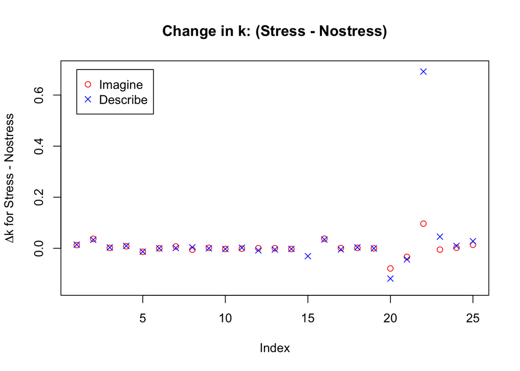

```r
#text(prompt_diff_stress, labels=k_df$subject)

# change in k = (stress - nostress)
##(stress - nostress) in describe, (stress - nostress) in imagine

session_diff_imagine <- k_df[k_df$session == 'stress' & k_df$prompt == 'imagine',]$k - k_df[k_df$session == 'nostress' & k_df$prompt == 'imagine',]$k
session_diff_describe <- k_df[k_df$session == 'stress' & k_df$prompt == 'describe',]$k - k_df[k_df$session == 'nostress' & k_df$prompt == 'describe',]$k
plot(session_diff_imagine, col = 'red', pch=1, ylim=c(-.15,.70),
     main="Change in k: (Stress - Nostress)", ylab=expression(paste(Delta,"k for Stress - Nostress")))
points(session_diff_describe, col = 'blue', pch=4)
legend(1, 0.7, legend=c("Imagine", "Describe"),
       col=c("red", "blue"), pch=c(1,4))
```

```r
#text(session_diff_imagine, labels=k_df$subject)

## plot change in k between sessions vs. Imagine/Describe, like above ggplot
k_session_diff <- k_df[k_df$session == 'stress',]$k - k_df[k_df$session == 'nostress',]$k
```

```r
# change in k = (imagine - describe). comparing delta k in stress session vs. nostress session.
t.test(prompt_diff_stress, prompt_diff_nostress)
```

```
##
##  Welch Two Sample t-test
##
## data:  prompt_diff_stress and prompt_diff_nostress
## t = 0.21984, df = 24.924, p-value = 0.8278
## alternative hypothesis: true difference in means is not equal to 0
## 95 percent confidence interval:
##  -0.08439722  0.10456413
## sample estimates:
##     mean of x     mean of y
##  0.0006274215 -0.0094560295
```

```r
# change in k = (stress - nostress). comparing delta k in imagine vs. describe trials.
t.test(session_diff_imagine, session_diff_describe)
```

```
##
##  Welch Two Sample t-test
##
## data:  session_diff_imagine and session_diff_describe
## t = 0.23017, df = 46.826, p-value = 0.819
## alternative hypothesis: true difference in means is not equal to 0
## 95 percent confidence interval:
##  -0.07805596  0.09822286
## sample estimates:
##  mean of x  mean of y
## 0.03619148 0.02610803
```

```r
# one-sample t-test on just the (imagine-describe) for stress session
t.test(prompt_diff_stress)
```

```
##
##  One Sample t-test
##
## data:  prompt_diff_stress
## t = 0.01381, df = 24, p-value = 0.9891
## alternative hypothesis: true mean is not equal to 0
## 95 percent confidence interval:
##  -0.09313983  0.09439467
## sample estimates:
##    mean of x
## 0.0006274215
```

## 8. Analyze Questionnaire Results

In the task, we collected participants’ responses to a few questionnaires:

**Session 1:**

- Pre-task:
  - BFNE
  - PSS
  - State version of PANAS
  - State version of STAI
- Post-task:
  - Demographics questionnaire
  - State version of PANAS
  - State version of STAI

**Session 2:**

- Pre-task:
  - State version of PANAS
  - State version of STAI
- Post-task:
  - State version of PANAS
  - State version of STAI

### STAI Questionnaire

Are participants’ state anxiety levels actually affected by the TSST? To test this, we need to compare participants’ anxiety scores between Session 1 and Session 2.

```r
# ALL STAI QUESTIONNAIRES
stai_subdf <- bigdf[bigdf$ttype == 'stai-1' | bigdf$ttype == 'stai-2', ]
stai_responses <- stai_subdf$responses

# edit contents of the cell to just have numbers
stai_responses <- str_replace(stai_responses, "[}]", "") # replace last bracket with nothing
stai_responses_split <- noquote(strsplit(stai_responses, "\\,|\\:")) # split by commas and colons
stai_responses_flat <- as.numeric(unlist(noquote(strsplit(stai_responses, "\\,|\\:"))))
stai_responses_flat <- stai_responses_flat[c(FALSE, TRUE)] # removes every other False value (extract every other column / element)
# create data.frame
stai_scores <- data.frame(matrix(stai_responses_flat, nrow=length(stai_responses_split), byrow=TRUE))
# rename columns in df
colnames(stai_scores) <- c("stai_q1","stai_q2","stai_q3","stai_q4","stai_q5","stai_q6","stai_q7",
  "stai_q8","stai_q9","stai_q10","stai_q11","stai_q12","stai_q13","stai_q14","stai_q15",
  "stai_q16","stai_q17","stai_q18","stai_q19","stai_q20")
# +1 to each numeric value in the cell
stai_scores <- stai_scores + 1
# reverse 10 anxiety-absent items in desired columns
reverse_cols = c('stai_q1', 'stai_q2', 'stai_q5', 'stai_q8', 'stai_q10', 'stai_q11', 'stai_q15', 'stai_q16', 'stai_q19', 'stai_q20')
stai_scores[,reverse_cols] = 5 - stai_scores[ ,reverse_cols]

# calculate total sum of points
for (i in 1:nrow(stai_scores)) {
  stai_scores$total[i] <- sum(stai_scores[i,1:20])
}

# create stai_df dataframe
subject <- stai_subdf$subject[stai_subdf$ttype == 'stai-1']
session <- stai_subdf$sessionlabel[stai_subdf$ttype == 'stai-1']
pretask <- stai_scores$total[stai_subdf$ttype == 'stai-1']
posttask <- stai_scores$total[stai_subdf$ttype == 'stai-2']
diff <- posttask-pretask
stai_df <- data.frame(subject=c(subject), session=c(session), pretask=c(pretask), posttask=c(posttask), diff=c(diff))
#stai_df
```

mean(diff_stress) = -0.52

mean(diff_nostress) = -3.72

- Black lines: these subjects had Nostress Session1, Stress Session2
- Gray lines: these subjects had Stress Session1, Nostress Session2

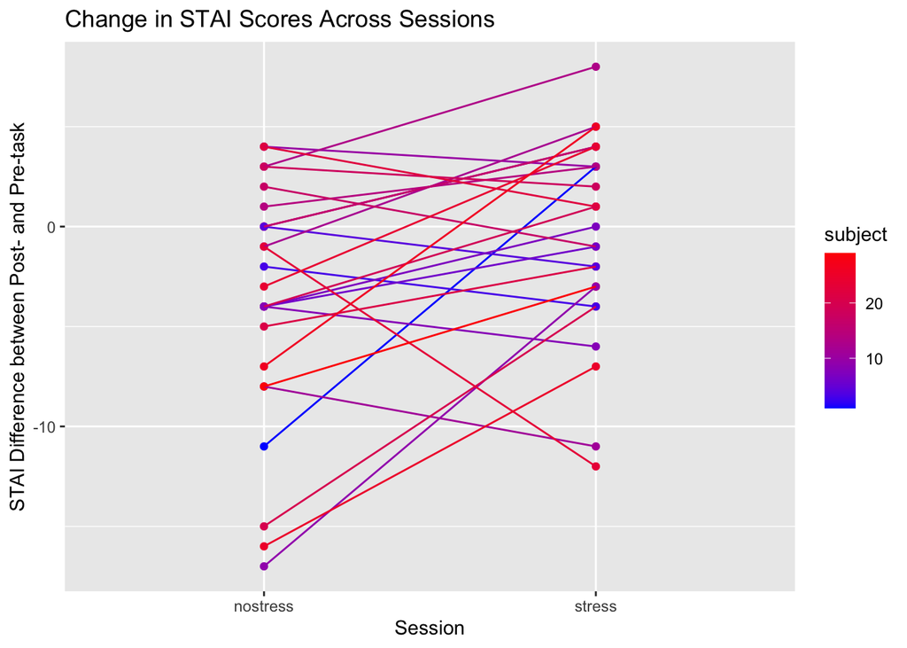

```r
# plot diff in stress vs. nostress
diff_stress <- stai_df$diff[stai_df$session == 'stress']
diff_nostress <- stai_df$diff[stai_df$session == 'nostress']
#plot(stai_df$session, stai_df$diff)

# Comparing Sessions
ggplot(stai_df, aes(x=as.factor(session), y=diff, color=subject)) +
  geom_point() +
  labs(y = "STAI Difference between Post- and Pre-task", x = "Session",
       title="Change in STAI Scores Across Sessions") +
  scale_color_gradient(low="blue", high="red") +
  geom_line(aes(group=interaction(subject))) #paired lines based on subject
```

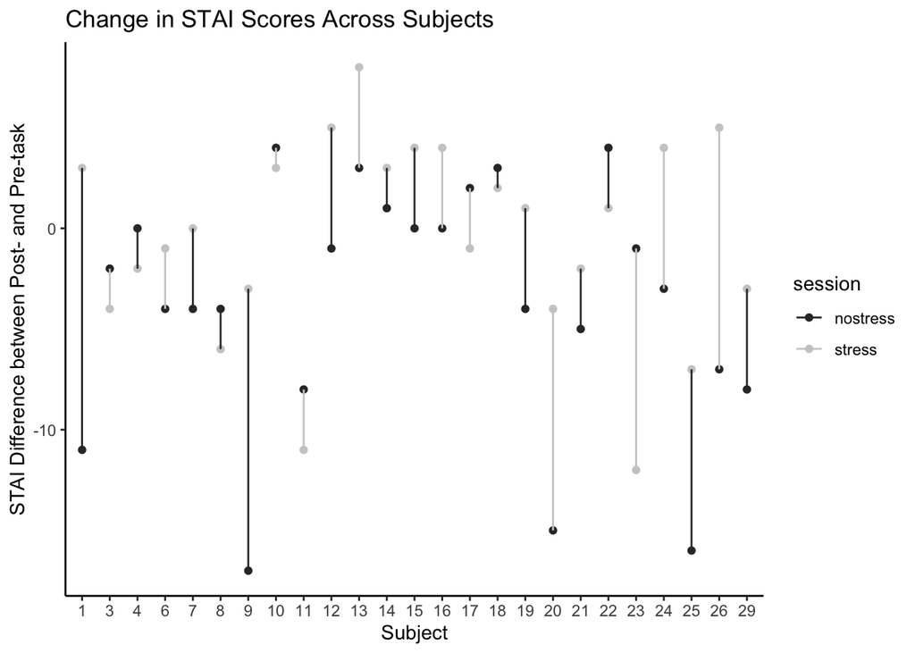

```r
# Comparing Subjects
ggplot(stai_df, aes(x=as.factor(subject), y=diff, color=session)) +
  geom_point() +
  labs(y = "STAI Difference between Post- and Pre-task", x = "Subject",
       title="Change in STAI Scores Across Subjects") +
  scale_color_grey() + theme_classic() +
  geom_line(aes(group=interaction(subject))) #paired lines based on subject
```

### Perceived Stress Scale

10 questions; reverse score Questions 4, 5, 7, 8

```r
pss_subdf <- bigdf[bigdf$ttype == 'pss', ]
pss_responses <- pss_subdf$responses

# edit contents of the cell to just have numbers
pss_responses <- str_replace(pss_responses, "[}]", "") # replace last bracket with nothing
pss_responses_split <- noquote(strsplit(pss_responses, "\\,|\\:")) # split by commas and colons
pss_responses_flat <- as.numeric(unlist(noquote(strsplit(pss_responses, "\\,|\\:"))))
pss_responses_flat <- pss_responses_flat[c(FALSE, TRUE)] # removes every other False value (extract every other column / element)
# create data.frame
pss_scores <- data.frame(matrix(pss_responses_flat, nrow=length(pss_responses_split), byrow=TRUE))
# rename columns in df
colnames(pss_scores) <- c("pss_q1","pss_q2","pss_q3","pss_q4","pss_q5","pss_q6","pss_q7",
  "pss_q8","pss_q9","pss_q10")

# reverse 4 stress-absent items in desired columns
reverse_cols = c('pss_q4', 'pss_q5', 'pss_q7', 'pss_q8')
pss_scores[,reverse_cols] = 4 - pss_scores[ ,reverse_cols]

# calculate total sum of points
for (i in 1:nrow(pss_scores)) {
  pss_scores$total[i] <- sum(pss_scores[i,1:10])
}

# create pss_df dataframe
subject <- pss_subdf$subject[pss_subdf$ttype == 'pss']
score <- pss_scores$total[pss_subdf$ttype == 'pss']
pss_df <- data.frame(subject=c(subject), score=c(score))

for (i in 1:nrow(pss_df)) {
  if (pss_df$score[i] %in% c(0:13)) {
    pss_df$traitstress[i] <- "low stress"
  } else if (pss_df$score[i] %in% c(14:26)) {
    pss_df$traitstress[i] <- "moderate stress"
  } else if (pss_df$score[i] %in% c(27:40)) {
    pss_df$traitstress[i] <- "high perceived stress"
  }
}
```

#### Relating Trait-level with State-level Stress

```r
# difference of STAI diff_nostress & diff_stress
session_diff <- diff_stress - diff_nostress

tsstlm <- lm(pss_df$score ~ session_diff)
summary(tsstlm)
```

```
##
## Call:
## lm(formula = pss_df$score ~ session_diff)
##
## Residuals:
##     Min      1Q  Median      3Q     Max
## -9.3870 -4.1581 -0.8954  4.5961 13.9817
##
## Coefficients:
##              Estimate Std. Error t value Pr(>|t|)
## (Intercept)   19.5268     1.3584  14.375 5.56e-13 ***
## session_diff   0.1229     0.2020   0.608    0.549
## ---
## Signif. codes:  0 '***' 0.001 '**' 0.01 '*' 0.05 '.' 0.1 ' ' 1
##
## Residual standard error: 5.973 on 23 degrees of freedom
## Multiple R-squared:  0.01583,    Adjusted R-squared:  -0.02696
## F-statistic: 0.3699 on 1 and 23 DF,  p-value: 0.549
```

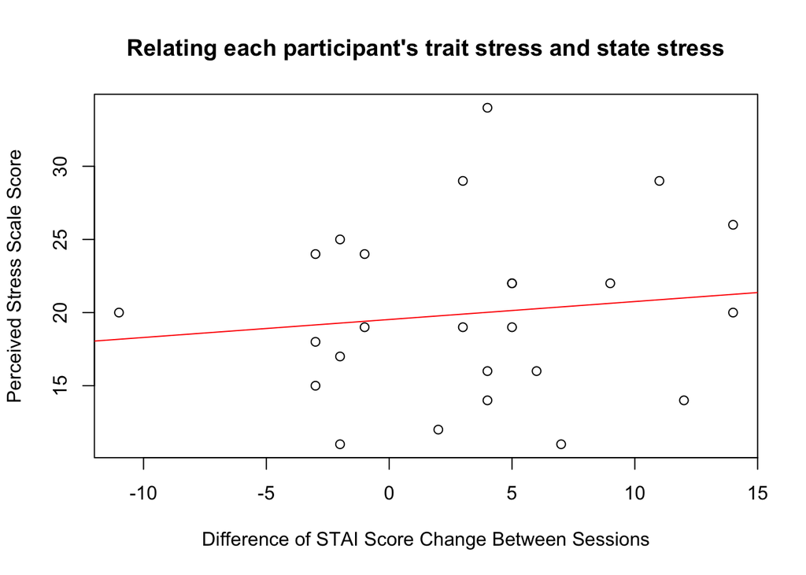

```r
# plot correlation between each participant's trait stress and session_diff (PSS trait ~ session_diff)
plot(pss_df$score ~ session_diff, col='black', pch=1, main="Relating each participant's trait stress and state stress", ylab="Perceived Stress Scale Score", xlab="Difference of STAI Score Change Between Sessions")
abline(tsstlm, col='red')
```

#### Relating state anxiety with proportion of choosing later reward

k diff between sessions ~ STAI

mixed effects model -> extract random effects (single Beta for each subject from glmer) -> relate this to STAI

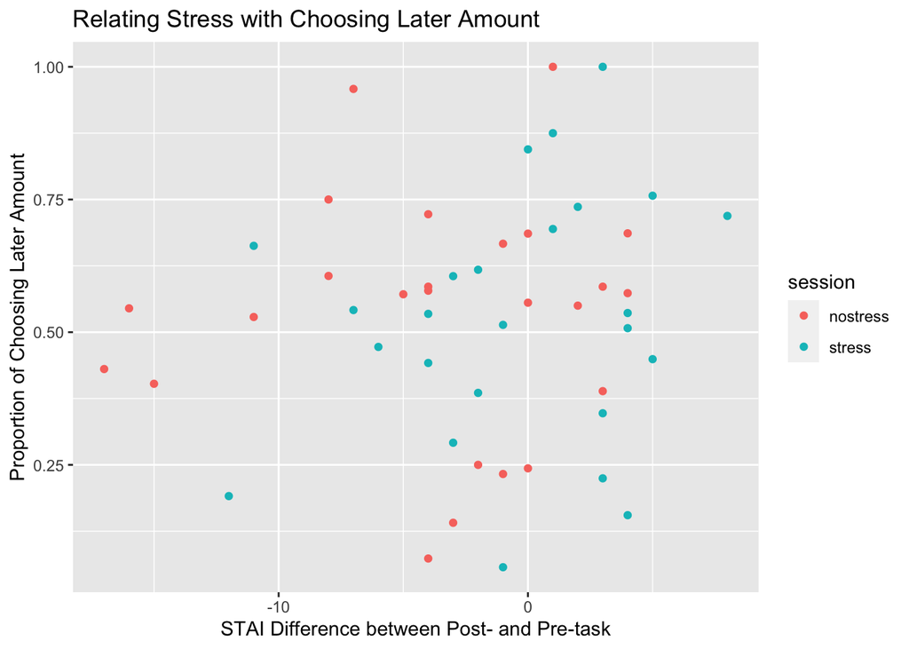

```r
# first find each participant's average prop.later for each session. (Each participant should have 2 items)
session.mean.prop <- tapply(k_df$prop.later, list(as.factor(k_df$subject), as.factor(k_df$session)), mean)
prop.mat <- melt(session.mean.prop, value.name="session.mean.prop", varnames=c('subject','session'))

prop_df <- data.frame(prop.mat)
stai_proplater_df <- merge(stai_df, prop_df) # join two dataframes with different col names

ggplot(stai_proplater_df, aes(x=diff, y=session.mean.prop, color=session)) +
  geom_point() +
  labs(x = "STAI Difference between Post- and Pre-task", y = "Proportion of Choosing Later Amount",
       title="Relating Stress with Choosing Later Amount")
```

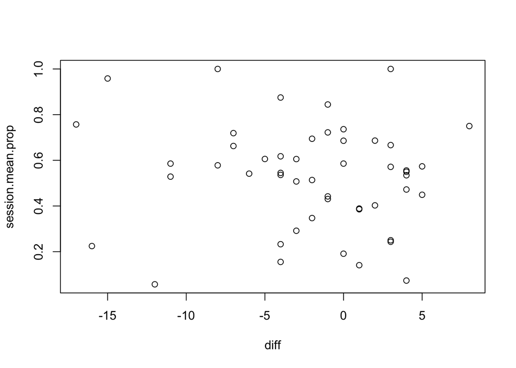

```r
  #scale_color_gradient(low="blue", high="red")

plot(diff, session.mean.prop)
```

```r
cor(stai_proplater_df$diff, stai_proplater_df$session.mean.prop)
```

```
## [1] 0.1117998
```

```r
diff_stress <- k_df$prop.later[k_df$session == 'stress']
diff_nostress <- k_df$prop.later[k_df$session == 'nostress']
session_diff_proplater = diff_stress - diff_nostress

# relate this to session_diff from stai_df
# session_diff_proplater ~ stai_df$session_diff
```

### Positive and Negative Affect Schedule [IN PROGRESS]

We can apply a similar structure to the PANAS questionnaires:

```r
panas_subdf <- bigdf[bigdf$ttype == 'panas-1' | bigdf$ttype == 'panas-2', ]
panas_responses <- panas_subdf$responses

# edit contents of the cell to just have numbers
panas_responses <- str_replace(panas_responses, "[}]", "") # replace last bracket with nothing
panas_responses_split <- noquote(strsplit(panas_responses, "\\,|\\:")) # split by commas and colons
panas_responses_flat <- as.numeric(unlist(noquote(strsplit(panas_responses, "\\,|\\:"))))
panas_responses_flat <- panas_responses_flat[c(FALSE, TRUE)] # removes every other False value (extract every other column / element)
# create data.frame
panas_scores <- data.frame(matrix(panas_responses_flat, nrow=length(panas_responses_split), byrow=TRUE))
# rename columns in df
colnames(panas_scores) <- c("panas_q1","panas_q2","panas_q3","panas_q4","panas_q5","panas_q6","panas_q7",
  "panas_q8","panas_q9","panas_q10","panas_q11","panas_q12","panas_q13","panas_q14","panas_q15",
  "panas_q16","panas_q17","panas_q18","panas_q19","panas_q20")
# +1 to each numeric value in the cell
panas_scores <- panas_scores + 1

# Positive Affect
positive_cols = c('panas_q1', 'panas_q3', 'panas_q5', 'panas_q9', 'panas_q10', 'panas_q12', 'panas_q14', 'panas_q16', 'panas_q17', 'panas_q19')
pos_panas <- panas_scores[,positive_cols]

# Negative Affect
negative_cols = c('panas_q2', 'panas_q4', 'panas_q6', 'panas_q7', 'panas_q8', 'panas_q11', 'panas_q13', 'panas_q15', 'panas_q18', 'panas_q20')
neg_panas <- panas_scores[,negative_cols]

# calculate total sum of points
for (i in 1:nrow(pos_panas)) {
  pos_panas$total[i] <- sum(pos_panas[i,1:10])
}

for (i in 1:nrow(neg_panas)) {
  neg_panas$total[i] <- sum(neg_panas[i,1:10])
}

# create panas_df dataframe
subject <- panas_subdf$subject[panas_subdf$ttype == 'panas-1']
session <- panas_subdf$sessionlabel[panas_subdf$ttype == 'panas-1']
pretask <- panas_scores$total[panas_subdf$ttype == 'panas-1']
posttask <- panas_scores$total[panas_subdf$ttype == 'panas-2']
diff <- posttask-pretask
panas_df <- data.frame(subject=c(subject), session=c(session), pretask=c(pretask), posttask=c(posttask), diff=c(diff))
#panas_df

# compare pos to pos, neg to neg?
```

## 9. Restricting participants included in analyses

### Subset participants based on STAI scores

Identify the participants who were “actually” impacted by the TSST (according to change in STAI scores). This only includes participants whose STAI scores increased more during Stress sessions than during No-stress sessions.

From 25 total included participants, 16 participants were impacted by the TSST: [subject %in% c(1,6,7,9,12,13,14,15,16,19,20,21,24,25,26,29), ]

By counterbalanced design, 11 participants experienced the TSST in their Session 1, and 14 experienced the TSST in Session 2. TSST in Session1: c(3,6,10,11,13,16,17,20,23,24,26)

Out of 11 with TSST in Session 1, 6 were impacted (and showed a higher positive change in STAI scores). Out of 14 with TSST in Session 2, 10 were impacted.

Out of the 16 participants who were impacted by the TSST, 6 of those had TSST in Session 1 (6, 13, 16, 20, 24, 26). The other 10 had TSST in Session 2.

```r
stressed_subjects = vector()

for (s in unique(stai_df$subject)) {
  if (stai_df[stai_df$subject == s & stai_df$session == 'stress',]$diff > stai_df[stai_df$subject == s & stai_df$session == 'nostress',]$diff) {
    stressed_subjects = c(stressed_subjects, s)
  }
}

stressed_subjects
```

```
##  [1]  1 12 13 14 15 16 19 20 21 24 25 26 29  6  7  9
```

Let’s look at prop.later and k again, but only for the participants who were impacted by the TSST:

```r
k_df_valid <- k_df[k_df$subject %in% c(1,6,7,9,12,13,14,15,16,19,20,21,24,25,26,29), ]

# take the mean across participants in a group
grouped.mean.proplater <- tapply(k_df_valid$prop.later, list(as.factor(k_df_valid$prompt), as.factor(k_df_valid$session)), mean)
grouped.mean.proplater
```

```
##           nostress    stress
## describe 0.5396388 0.5188054
## imagine  0.5680789 0.5519374
```

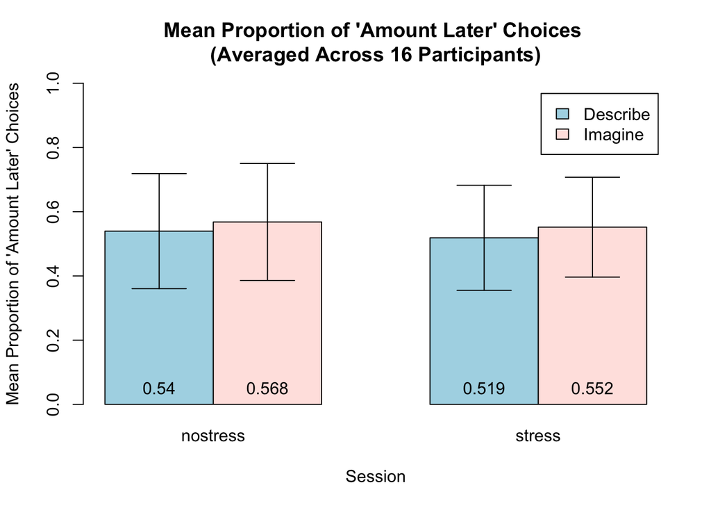

```r
# Remove 'between-subject variability'
## within each subject, calculate mean prop.later to average out the 4 sessions per subject
subject.mean = tapply(k_df_valid$prop.later, list(as.factor(k_df_valid$subject)), mean)
sample.mean = mean(k_df_valid$prop.later)

# normalize prop.later within each subject
#prop.later.adj = prop.later - subject.mean + sample.mean
counter = 1
for (i in unique(k_df_valid$subject)) {
  k_df_valid$prop.later.adj[k_df_valid$subject == i] = k_df_valid$prop.later[k_df_valid$subject == i] - subject.mean[counter] + sample.mean
  counter = counter + 1
}

# Create within-subject error bars
## standard deviation of adjusted prop.later
standard.deviation = tapply(k_df_valid$prop.later.adj, list(as.factor(k_df_valid$prompt), as.factor(k_df_valid$session)), sd)

# get 4 standard errors for each Group
standard.error = (standard.deviation)/(sqrt(length(unique(k_df_valid$subject))))
upper = grouped.mean.proplater + 1.96*(standard.error)
lower = grouped.mean.proplater - 1.96*(standard.error)

bp.prop.later <- barplot2(grouped.mean.proplater, beside=TRUE,
      main="Mean Proportion of 'Amount Later' Choices \n(Averaged Across 16 Participants)",
      ylim=c(0,1), col=c("lightblue", "mistyrose"),
      plot.ci=TRUE, ci.u=upper, ci.l=lower,
      #names.arg = c("Stress Imagine", "Stress Describe", "Nostress Imagine", "Nostress Describe"),
      xlab="Session", ylab="Mean Proportion of 'Amount Later' Choices",
      legend=c("Describe","Imagine"))
      #args.legend=list(title="Prompt", x="topright", cex=.7))

text(bp.prop.later, 0, round(grouped.mean.proplater,3), cex=1, pos=3)
```

```r
# take the mean across participants in a group
grouped.mean.k <- tapply(k_df_valid$k, list(as.factor(k_df_valid$prompt), as.factor(k_df_valid$session)), mean)
grouped.mean.k
```

```
##            nostress     stress
## describe 0.03067820 0.08094610
## imagine  0.01833921 0.02799701
```

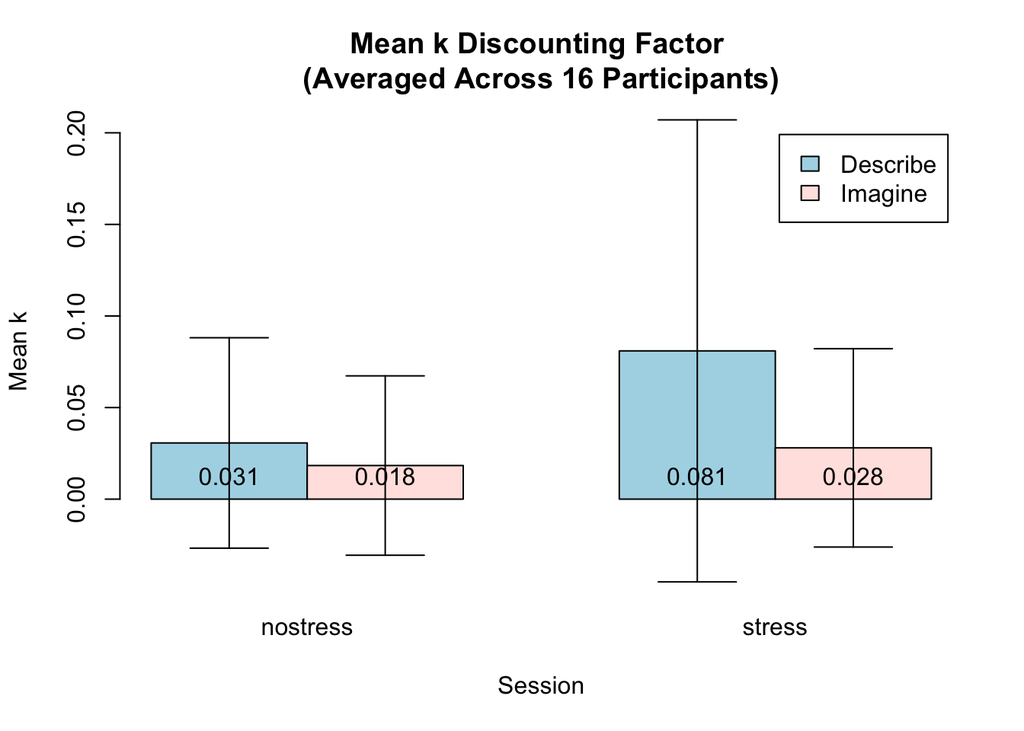

```r
# Remove 'between-subject variability'
## within each subject, calculate mean prop.later to average out the 4 sessions per subject
subject.mean = tapply(k_df_valid$k, list(as.factor(k_df_valid$subject)), mean)
sample.mean = mean(k_df_valid$k)

# normalize prop.later within each subject
#k.adj = k - subject.mean + sample.mean
counter = 1
for (i in unique(k_df_valid$subject)) {
  k_df_valid$k.adj[k_df_valid$subject == i] = k_df_valid$k[k_df_valid$subject == i] - subject.mean[counter] + sample.mean
  counter = counter + 1
}

# Create within-subject error bars
## standard deviation of adjusted prop.later
standard.deviation = tapply(k_df_valid$k.adj, list(as.factor(k_df_valid$prompt), as.factor(k_df_valid$session)), sd)

# get 4 standard errors for each Group
standard.error = (standard.deviation)/(sqrt(length(unique(k_df_valid$subject))))
upper = grouped.mean.k + 1.96*(standard.error)
lower = grouped.mean.k - 1.96*(standard.error)

bp.k <- barplot2(grouped.mean.k, beside=TRUE,
      main="Mean k Discounting Factor \n(Averaged Across 16 Participants)",
      col=c("lightblue", "mistyrose"),
      plot.ci=TRUE, ci.u=upper, ci.l=lower,
      xlab="Session", ylab="Mean k",
      legend=c("Describe","Imagine"))

text(bp.k, 0, round(grouped.mean.k,3), cex=1, pos=3)
```

## 10. Splitting trials into first half/second half

What happens when we split the trials into first half/second half and then compare them?

Within participants: break up trials into 1st half of trials, 2nd half of trials. Check if there’s an overall trend for choselater=1. (Do participants get tired of making decisions near the end of the task?)

prop.later in 1st half vs. 2nd half

It looks like there isn’t much of a difference between the trials in the first half and second half. Participants tend to be pretty consistent throughout the experiment session.

```r
# binary split trials into 1st half (beginning) and 2nd half (end)

# take the mean across participants in a session
grouped.mean.beginning <- tapply(split_df$prop.later.beginning, list(as.factor(split_df$session)), mean)
grouped.mean.beginning
```

```
##  nostress    stress
## 0.5256078 0.5204377
```

```r
grouped.mean.end <- tapply(split_df$prop.later.end, list(as.factor(split_df$session)), mean)
grouped.mean.end
```

```
##  nostress    stress
## 0.5386835 0.5321550
```

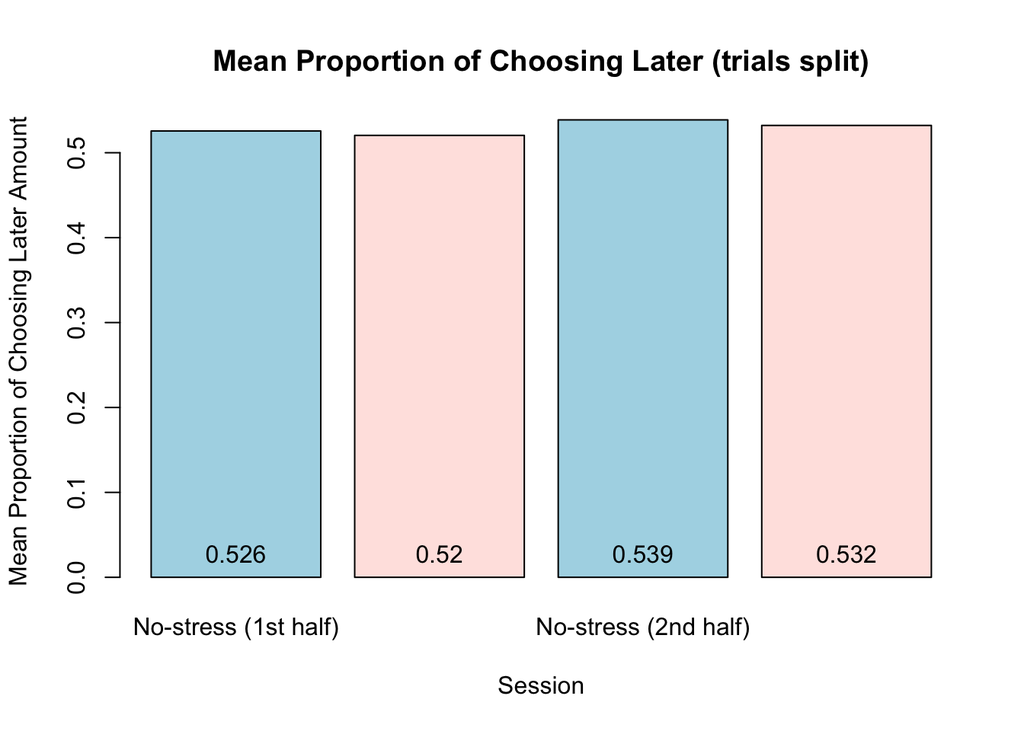

```r
bp.split <- barplot2(c(grouped.mean.beginning,grouped.mean.end), beside=TRUE,
      main="Mean Proportion of Choosing Later (trials split)",
      #ylim=c(0,1800),
      col=c("lightblue", "mistyrose"),
      #plot.ci=TRUE, ci.u=upper, ci.l=lower,
      names.arg = c("No-stress (1st half)", "Stress (1st half)", "No-stress (2nd half)", "Stress (2nd half)"),
      xlab="Session", ylab="Mean Proportion of Choosing Later Amount")

text(bp.split, 0, round(c(grouped.mean.beginning,grouped.mean.end),3), cex=1, pos=3)
```

## 11. Reaction Times

Find overall average RT per condition:

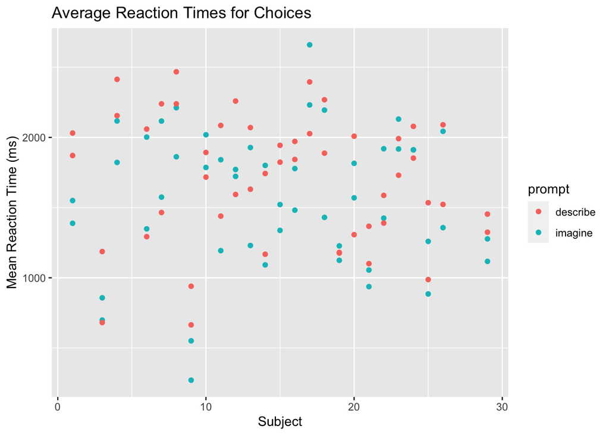

```r
ggplot(k_df, aes(x=subject, y=mean.rt, color=prompt)) +
  geom_point() +
  labs(y = "Mean Reaction Time (ms)", x = "Subject",
       title="Average Reaction Times for Choices")
```

```r
# take the mean across participants in a group
grouped.mean.rt <- tapply(k_df$mean.rt, list(as.factor(k_df$prompt), as.factor(k_df$session)), mean)
grouped.mean.rt
```

```
##          nostress   stress
## describe 1729.455 1676.488
## imagine  1583.242 1547.636
```

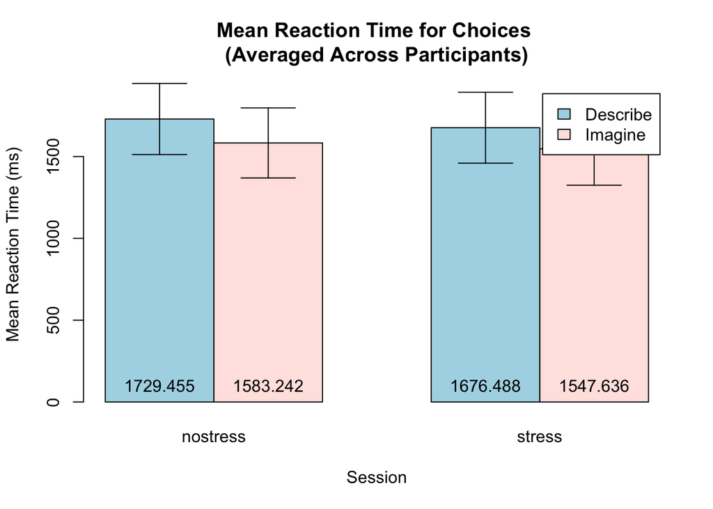

```r
# Remove 'between-subject variability'
## within each subject, calculate mean prop.later to average out the 4 sessions per subject
subject.mean = tapply(k_df$mean.rt, list(as.factor(k_df$subject)), mean)
sample.mean = mean(k_df$mean.rt)

# normalize prop.later within each subject
#k.adj = k - subject.mean + sample.mean
counter = 1
for (i in unique(k_df$subject)) {
  k_df$mean.rt.adj[k_df$subject == i] = k_df$mean.rt[k_df$subject == i] - subject.mean[counter] + sample.mean
  counter = counter + 1
}

# Create within-subject error bars
## standard deviation of adjusted prop.later
standard.deviation = tapply(k_df$mean.rt.adj, list(as.factor(k_df$prompt), as.factor(k_df$session)), sd)

# get 4 standard errors for each Group
standard.error = (standard.deviation)/(sqrt(length(unique(k_df$subject))))
upper = grouped.mean.rt + 1.96*(standard.error)
lower = grouped.mean.rt - 1.96*(standard.error)

bp.mean.rt <- barplot2(grouped.mean.rt, beside=TRUE,
      main="Mean Reaction Time for Choices \n(Averaged Across Participants)",
      #ylim=c(0,1800),
      col=c("lightblue", "mistyrose"),
      plot.ci=TRUE, ci.u=upper, ci.l=lower,
      #names.arg = c("Stress Imagine", "Stress Describe", "Nostress Imagine", "Nostress Describe"),
      xlab="Session", ylab="Mean Reaction Time (ms)",
      legend=c("Describe","Imagine"))

text(bp.mean.rt, 0, round(grouped.mean.rt,3), cex=1, pos=3)
```

Interaction plot for order effects (subs with stress first) DV: choselater

## 12. Text Response Analysis

Create a data frame (“text_df”) where you organize all the text responses for each participant. Combine to get an aggregate of text responses per participant.

*how many words* the participants write for writeout, whether that corresponds to choices at all (choselater)

Use text analyses (NLP programs; TreeTagger; LIWC) to help analyzes POS, abstract vs. concrete details in txt.

Append all the text responses from each group, feed into POS Tagger, and output proportion of adj, nouns, verbs, etc.

```r
writeout_subdf <- bigdf[bigdf$ttype == 'imagine_writeout' | bigdf$ttype == 'describe_writeout', ]

# edit contents of the cell to just have relevant text
writeout_subdf$responses <- str_replace(writeout_subdf$responses, "[}]", "")
writeout_subdf$responses <- str_replace(writeout_subdf$responses, "[{]", "")
writeout_subdf$responses <- str_replace(writeout_subdf$responses, "writeout", "")
writeout_subdf$responses <- str_replace(writeout_subdf$responses, "[:]", "")

#writeout_responses <- as.character(gsub("writeout", "", writeout_subdf$responses))
#writeout_responses <- as.character(gsub(":", "", writeout_responses))

text_df = data.frame(subject=writeout_subdf$subject, session=writeout_subdf$sessionlabel,
                     prompt=writeout_subdf$ttype, text=writeout_subdf$responses,
                     amountlater=writeout_subdf$amountlater, delay=writeout_subdf$delay,
                     scene=writeout_subdf$scene)

# save local copy of text_df
path_out = '~/Box Sync/Bakkour-Lab/users/hayoung/stress_prospection_data/SONA_prelim_analysis/'
fileName = paste(path_out, 'text_df.csv', sep='')
write.csv(text_df, fileName, row.names=FALSE)

numwords <- sapply(strsplit(text_df$text, " "), length) # split response string by spaces & count length of response
text_df = cbind(text_df, numwords)

# average numwords in imagine_writeout vs. describe_writeout
# take the mean across participants in a group
grouped.mean.numwords <- tapply(text_df$numwords, list(as.factor(text_df$prompt),
                                                       as.factor(text_df$session)), mean)
grouped.mean.numwords
```

```
##                   nostress stress
## describe_writeout 49.95333  46.20
## imagine_writeout  52.50667  49.26
```

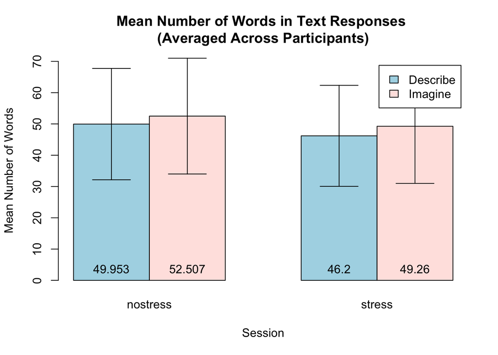

```r
# Remove 'between-subject variability'
subject.mean = tapply(text_df$numwords, list(as.factor(text_df$subject)), mean)
sample.mean = mean(text_df$numwords)

# normalize prop.later within each subject
#k.adj = k - subject.mean + sample.mean
counter = 1
for (i in unique(text_df$subject)) {
  text_df$numwords.adj[text_df$subject == i] = text_df$numwords[text_df$subject == i] - subject.mean[counter] + sample.mean
  counter = counter + 1
}

# Create within-subject error bars
## standard deviation of adjusted prop.later
standard.deviation = tapply(text_df$numwords.adj, list(as.factor(text_df$prompt), as.factor(text_df$session)), sd)

# get 4 standard errors for each Group
standard.error = (standard.deviation)/(sqrt(length(unique(text_df$subject))))
upper = grouped.mean.numwords + 1.96*(standard.error)
lower = grouped.mean.numwords - 1.96*(standard.error)

bp.mean.numwords <- barplot2(grouped.mean.numwords, beside=TRUE,
      main="Mean Number of Words in Text Responses \n(Averaged Across Participants)",
      #ylim=c(0,1800),
      col=c("lightblue", "mistyrose"),
      plot.ci=TRUE, ci.u=upper, ci.l=lower,
      #names.arg = c("Stress Imagine", "Stress Describe", "Nostress Imagine", "Nostress Describe"),
      xlab="Session", ylab="Mean Number of Words",
      legend=c("Describe","Imagine"))

text(bp.mean.numwords, 0, round(grouped.mean.numwords,3), cex=1, pos=3)
```

### Sentiment Analysis

Text mining with R using a tidy approach: First, we need to convert text response data (`text_df`) into a tidy text format so that we can pursue questions about word frequency and sentiment analysis / opinion mining.

Reference: https://www.tidytextmining.com/sentiment.html

```r
#restructure as one-token-per-row format
tidy_text <- text_df %>%
  unnest_tokens(word, text)

#remove stop words (extremely common words)
data(stop_words)

tidy_text <- tidy_text %>%
  anti_join(stop_words)
```

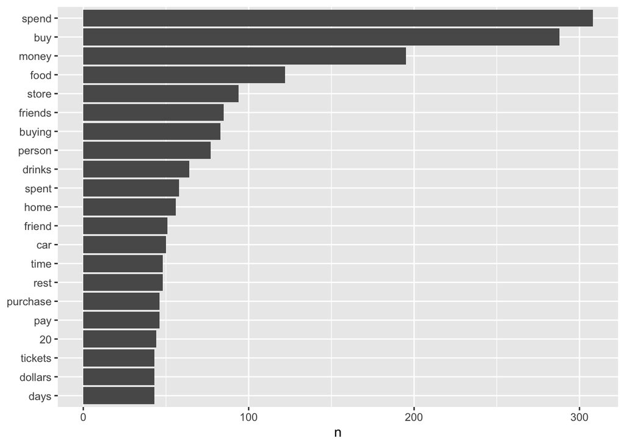

```r
#find the most common words in all text responses as a whole
# tidy_text %>%
#   dplyr::count(word, sort = TRUE)

#visualization of most common words
tidy_text %>%
  dplyr::count(word, sort = TRUE) %>%
  filter(n > 40) %>%
  mutate(word = reorder(word, n)) %>%
  ggplot(aes(n, word)) +
  geom_col() +
  labs(y = NULL)
```

```r
# afinn dictionary
afinn <- get_sentiments("afinn")

tidy_text %>%
  inner_join(afinn) %>%
  dplyr::count(word, sort = TRUE)
# nrc dictionary
nrc_joy <- get_sentiments("nrc") %>%
  filter(sentiment == "joy")

tidy_text %>%
  inner_join(nrc_joy) %>%
  count(word, sort = TRUE)
```

[output not shown]

```r
# filter(session == "nostress")
# library(textdata)
# library(wordcloud)
#
```

End of script.